# ECO 395 Homework 1

Minjin Kang, Paul Park

2023-01-21

## 1) Data visualization: flights at ABIA

**Question: What is the best time of year to fly to minimize delays, and does this change by destination?**

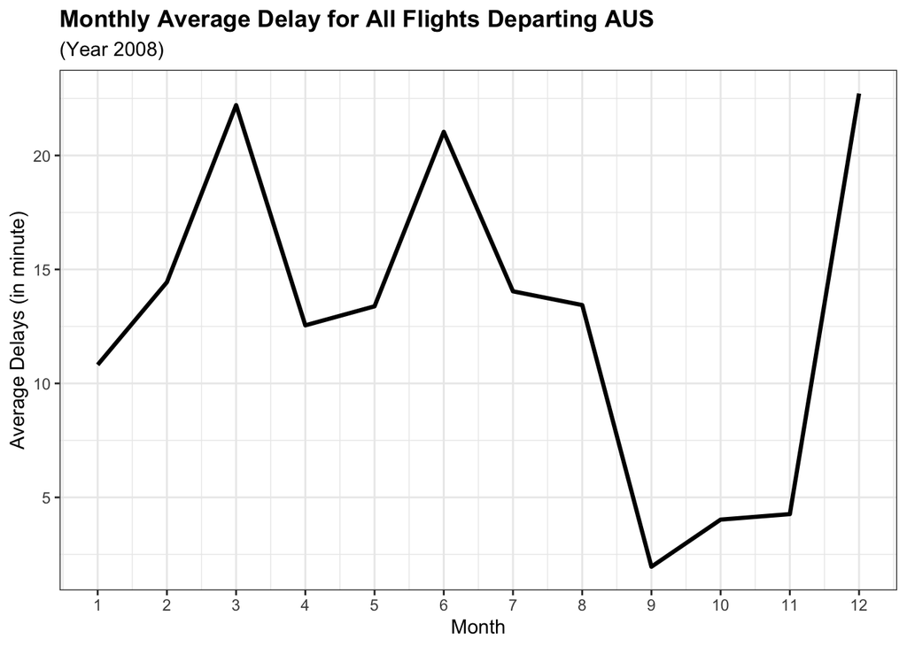

**Figure 1:** Line graph showing monthly average delay time for 49,623 flights that departed from AUS in 2008.

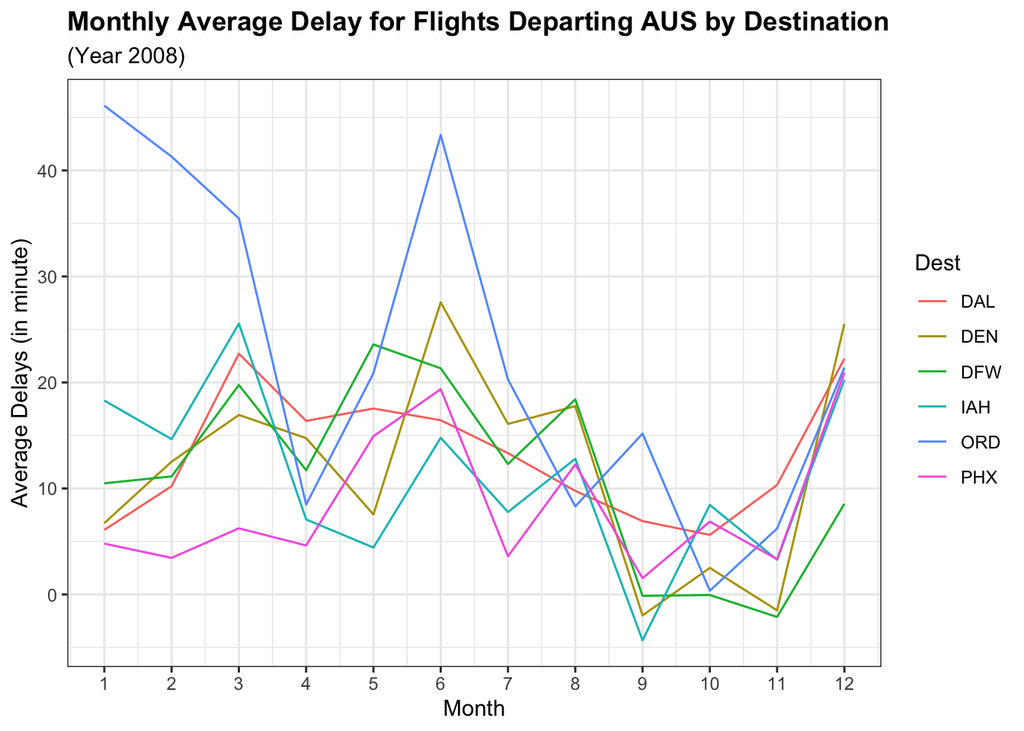

**Figure 2:** Line graph showing monthly average delay time for 22,740 flights that departed from AUS to the six most popular destination airports in 2008.

Next, we wanted to find out whether the result changes by destination. We picked six most popular destinations, which are Dallas Love Field Airport (DAL), Denver International Airport (DEN), Dallas/Fort Worth International Airport (DFW), George Bush Intercontinental Airport (IAH), Chicago O’Hare International Airport (ORD), Phoenix Sky Harbor International Airport (PHX). Figure 2 shows that the overall trend of delays throughout the year is similar to that shown by Figure 1. In general, September and October seem to be the months with the least flight delays.

## 2) Wrangling the Olympics

#### A) What is 95th percentile of heights for female competitiors across Athletics events?

```
## 95%
## 183
```

95th percentile of heights for female competitors across Athletcis events is 183cm.

#### B) Which single women’s event had the greatest variability in competitor’s heights across the entire history of the Olympics, as measured by the standard deviation?

| Event | Height Variability |
| --- | --- |
| Rowing Women’s Coxed Fours | 10.86549 |

Rowing Women’s Coxed Fours has the greatest variability in women competitor’s heights across the entire history of the Olympics.

#### C) How has the average age of Olympic swimmers changed over time? Does this trend look different depending on the gender?

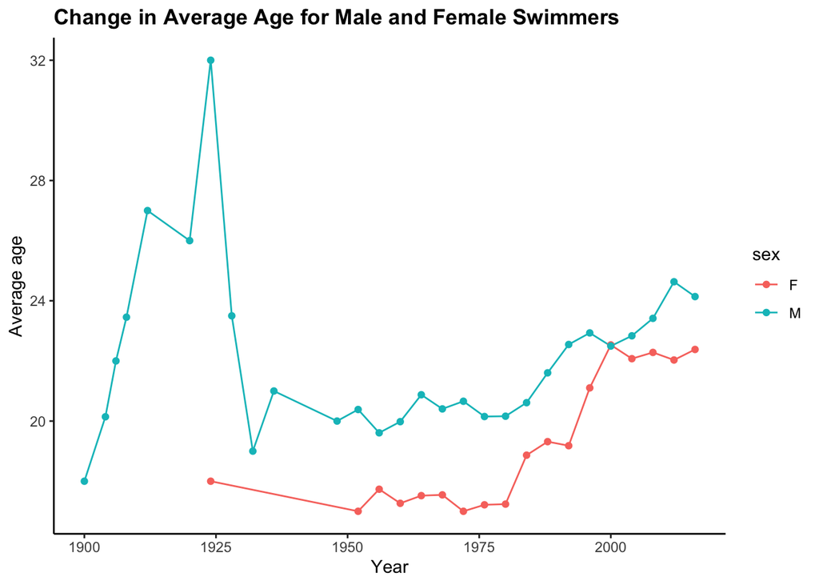

## 3) K-nearest neighbors: cars

### Car trim level 350

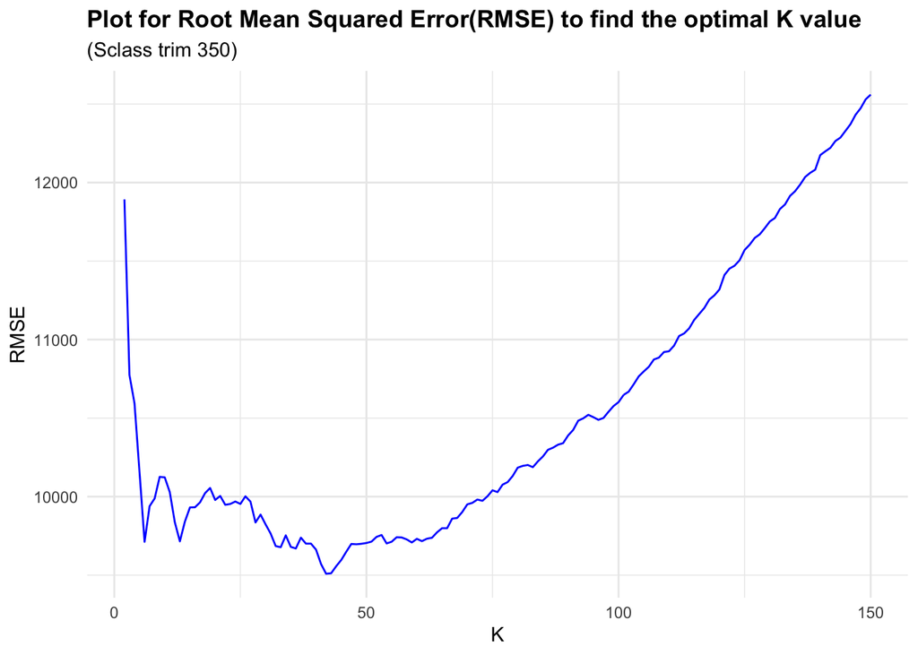

**Figure 1:** Plot showing RMSE for each value of K (from 2 to 150)

Here, we can see which K value has the lowest RMSE, and this is the optimal value of K

**Optimal value of K**

```
## [1] 42
```

**RMSE from the Optimal value of K**

```
## [1] 9508.806
```

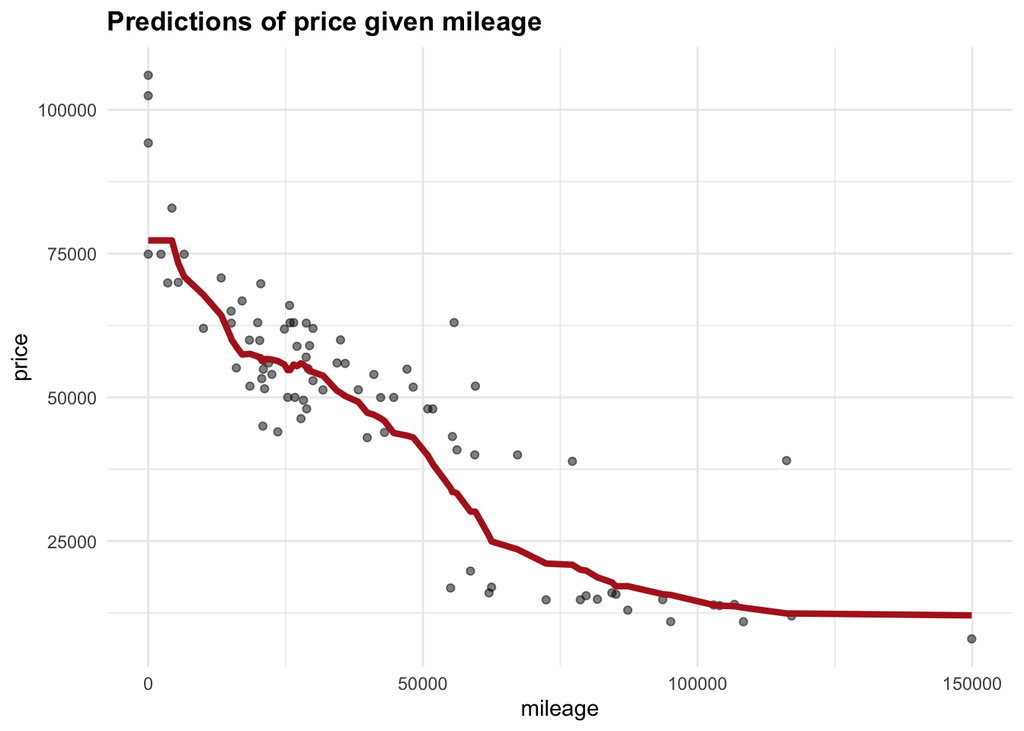

**Figure 2:** Plot of the fitted model, predicted price and real price

### Car trim level 65 AMG

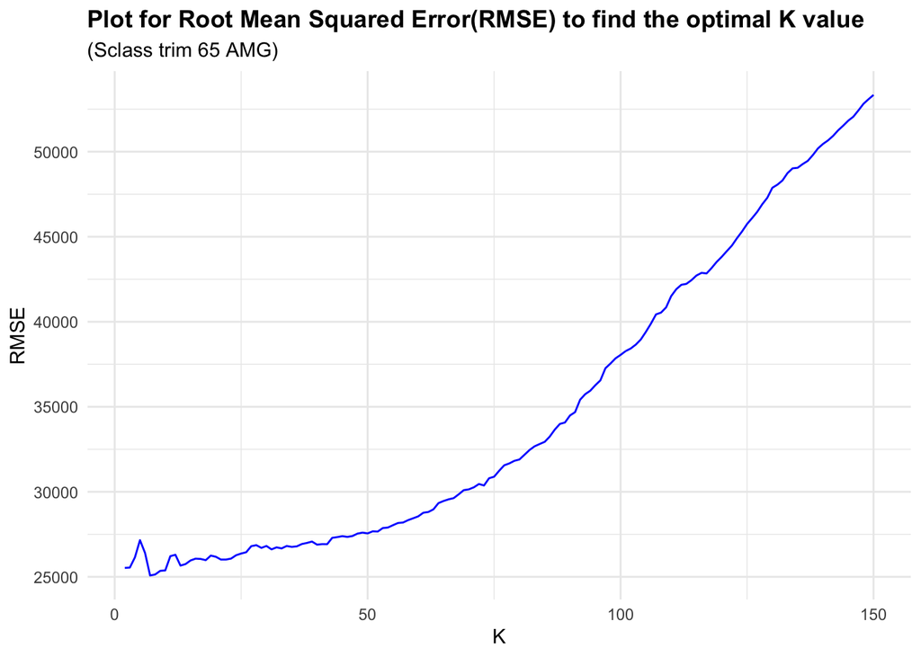

**Figure 3:** Plot showing RMSE for each value of K (from 2 to 150)

Here, we can see which K value has the lowest RMSE, and this is the optimal value of K

**Optimal value of K**

```
## [1] 7
```

**RMSE from the Optimal value of K**

```
## [1] 25079.13
```

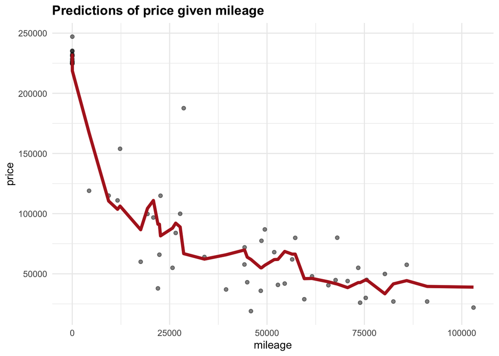

**Figure 4:** Plot of the fitted model, predicted price and real price

**Result: Trim 350 yields a larger optimal value of K**

|  | Trim 350 | Trim 65 AMG |
| --- | --- | --- |
| Number of rows | 416 | 292 |

Trim 350 has larger optimal K value as it contains more data points than trim 65 AMG. More data points means lower variance, less chance of memorizing random noise.